# Simple Income Inequality

##### Plot all years

This plots the actual and adjusted income distributions for all years.

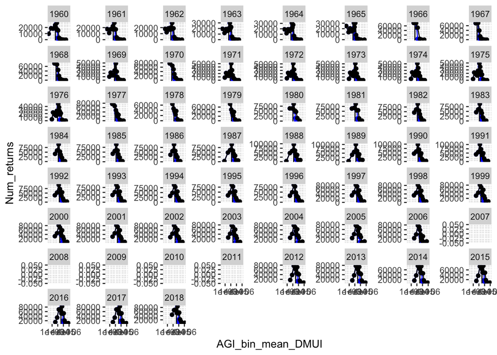

```r
ggplot(inc_ineq)+
  geom_point(aes(AGI_bin_mean_DMUI,Num_returns),color="blue")+
  geom_path(aes(AGI_bin_mean_DMUI,Num_returns),color="blue")+
  geom_point(aes(AGI_bin_mean,Num_returns))+
  geom_path(aes(AGI_bin_mean,Num_returns))+
  facet_wrap("Year",scales="free_y")+
  scale_x_log10()+
  geom_vline(data=Y_med,aes(xintercept=Median))
```

### Sufficiency threshold-based adjustment

We start by reading in the data for the sufficiency thresholds, and taking a look at the dataset. We had one sufficiency threshold set by ALICE and a second threshold by DBEDT, which is the one we opted to use. The DBEDT one-adult self-sufficiency income threshold (state: $35,143 in 2018) is from the Self Sufficiency Income Standard Report (https://files.hawaii.gov/dbedt/economic/reports/self-sufficiency/self-sufficiency_2018.pdf). We adjusted the 2018 value for inflation to get previous and future years. Other years for which sufficiency thresholds exist (2009, 2011, 2013, 2014, 2016) were not incorporated. As more data become available, future iterations could vary the sufficiency thresholds by year in the input file.

```r
suff_th <- read_csv("Suff_thresh_INQ_clean.csv")
#head(suff_th)
```

Now we want to run the DMUI function using the sufficiency threshold, and add the ratio to the output dataframe

```r
inc_ineq$AGI_ST_DMUI=DMUI(x = inc_ineq$AGI_bin_mean,m=suff_th$DBEDT_S[match(inc_ineq$Year,suff_th$YEAR)])

Ysum_ST <- inc_ineq %>%
  group_by(Year) %>%
  summarize(AGI_ann=sum(AGI_USD_all),
            AGI_ann2=sum(AGI_bin_mean*Num_returns),
            AGI_annSTDMUI=sum(AGI_ST_DMUI*Num_returns))
#view(Ysum_ST)

Ysum_ST$DMUI_Ratio_ST=Ysum_ST$AGI_annSTDMUI/Ysum_ST$AGI_ann
```

We create the output files for the sufficiency threshold and for both methods

```r
output_ST<-Ysum_ST %>% select(Year,DMUI_Ratio_ST)
#output_ST<-Ysum_ST[,c("Year","DMUI_Ratio_ST")]

write_csv(output_ST,"DMUI_Ratio_ST.csv")

#Create a combined data file
output_all <- left_join(output_M, output_ST)
write_csv(output_all,"DMUI_Ratio_both.csv")
```

#### Plots - sufficiency threshold

We plot the DMUI ratio based on sufficiency threshold

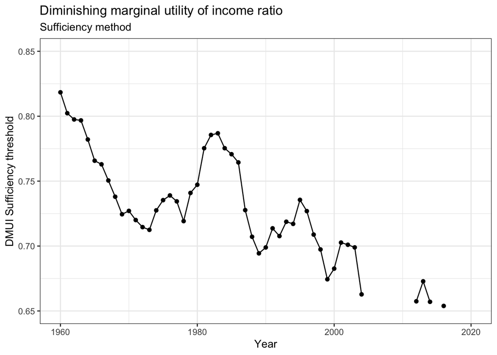

```r
#plot(Ysum_ST$Year,Ysum_ST$DMUI_Ratio_ST)

ggplot(output_ST,
  aes(x=Year, y=DMUI_Ratio_ST)) +
  geom_point() +
  geom_path() +
  labs(title = "Diminishing marginal utility of income ratio", subtitle = "Sufficiency method") +
  scale_x_continuous(name = "Year",limits=c(1960,2020)) +
  scale_y_continuous(name = "DMUI Sufficiency threshold", limits=c(0.65, 0.85)) +
  theme_bw()
```

This compares the two ratios

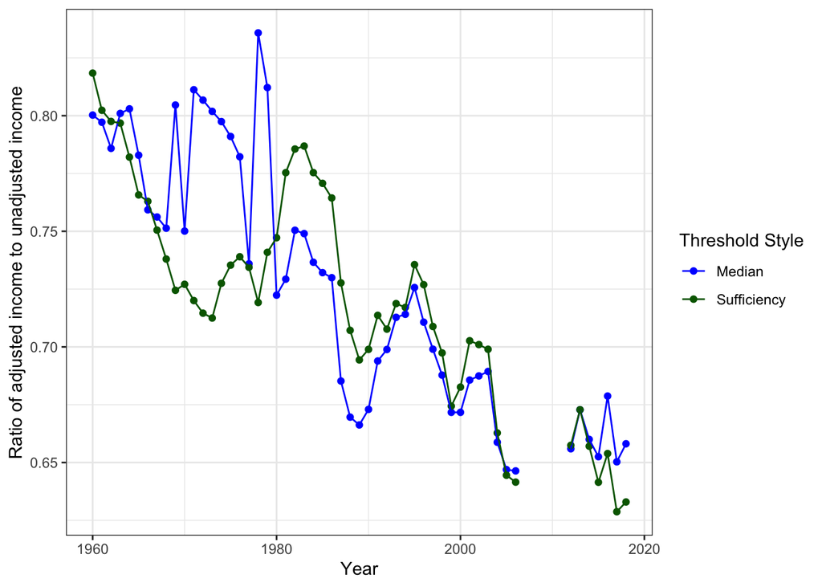

```r
oa_plot=output_all %>% pivot_longer(cols=c("DMUI_Ratio","DMUI_Ratio_ST"))

ggplot(oa_plot, aes(x = Year, y = value,color=name)) +
  geom_point(aes()) +
  geom_path(aes()) +
  scale_color_discrete(name="Threshold Style",type=c("blue","darkgreen"),labels=c("Median","Sufficiency")) +
  labs(x = "Year",
       y = "Ratio of adjusted income to unadjusted income",
       color = "Legend") +
  theme_bw()
```

## GINI for comparison

To build intuition, we examine income inequality using a traditional indicator, the GINI coefficient. For various reasons, GINI is a poor indicator for Hawaii. We use the same income data as above.

```r
#calculate the GINI to test
Gini_ii <- inc_ineq %>%
  group_by(Year) %>%
  summarise(G=Gini(x=Bracket_mid, n=Num_returns,na.rm=T))
Gini_ii
```

```
## # A tibble: 59 × 2
##     Year     G
##    <dbl> <dbl>
##  1  1960 0.454
##  2  1961 0.469
##  3  1962 0.470
##  4  1963 0.466
##  5  1964 0.467
##  6  1965 0.489
##  7  1966 0.418
##  8  1967 0.400
##  9  1968 0.414
## 10  1969 0.439
## # … with 49 more rows
```

```r
Gini_iiagi <- inc_ineq %>%
  group_by(Year) %>%
  summarise(G=Gini(x=AGI_bin_mean, n=Num_returns,na.rm=T))
Gini_iiagi
```

```
## # A tibble: 59 × 2
##     Year     G
##    <dbl> <dbl>
##  1  1960 0.444
##  2  1961 0.452
##  3  1962 0.460
##  4  1963 0.454
##  5  1964 0.454
##  6  1965 0.481
##  7  1966 0.368
##  8  1967 0.387
##  9  1968 0.401
## 10  1969 0.428
## # … with 49 more rows
```

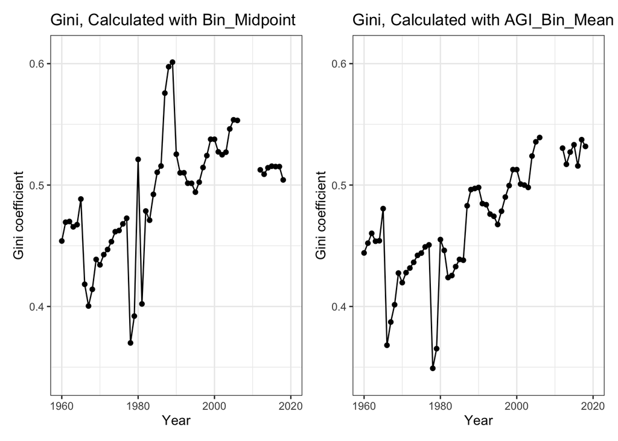

```r
#Plot
gii=ggplot(Gini_ii,
       aes(Year,G)) +
  geom_point()+geom_path() +
  labs(title = "Gini, Calculated with Bin_Midpoint") +
  scale_x_continuous(name="Year",limits=c(1960,2020))+
  scale_y_continuous(name="Gini coefficient",limits=c(.34,.61))+
  theme_bw()

giia=ggplot(Gini_iiagi,
       aes(Year,G)) +
  geom_point()+geom_path() +
  labs(title = "Gini, Calculated with AGI_Bin_Mean") +
  scale_x_continuous(name="Year",limits=c(1960,2020))+
  scale_y_continuous(name="Gini coefficient",limits=c(.34,.61))+
  theme_bw()

gii+giia
```